# Reproducible Research: Peer Assessment 1

## Loading and preprocessing the data

Load Activity Monitoring dataset and view dataset summary:

```r
activity <- read.csv("activity.csv")
str(activity)
```

```
## 'data.frame':    17568 obs. of  3 variables:
##  $ steps   : int  NA NA NA NA NA NA NA NA NA NA ...
##  $ date    : Factor w/ 61 levels "2012-10-01","2012-10-02",..: 1 1 1 1 1 1 1 1 1 1 ...
##  $ interval: int  0 5 10 15 20 25 30 35 40 45 ...
```

Convert “date” variable to date format:

```r
activity$date <- as.Date(as.character(activity$date))
```

## What is mean total number of steps taken per day?

Aggregate total number of steps by day:

```r
aggregated_activity <- aggregate(steps~date, data = activity,FUN = "sum" )
```

Create histogram of the total number of steps taken each day:

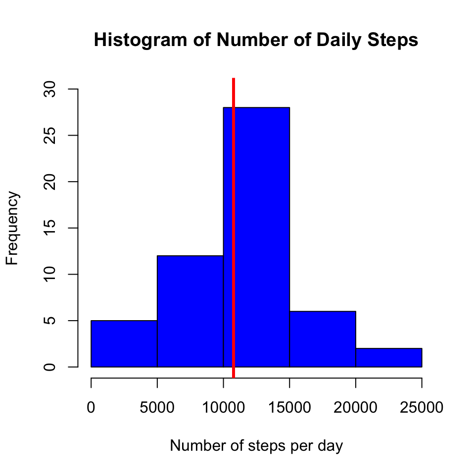

```r
hist(aggregated_activity$steps, col = "blue", main = "Histogram of Number of Daily Steps", xlab = "Number of steps per day", ylim = c(0,30))
abline(v = median(aggregated_activity$steps), col = "red", lwd = 3)
```

Calculate the mean and median of the total steps taken each day:

```r
print(mean <- mean(aggregated_activity$steps))
```

```
## [1] 10766.19
```

```r
print(median <- median(aggregated_activity$steps))
```

```
## [1] 10765
```

## What is the average daily activity pattern?

Compute average number of steps per interval, averaged accross all days :

```r
steps_per_interval <- aggregate(steps~interval, data = activity,FUN = "mean" )
```

Plot average number of steps against interval:

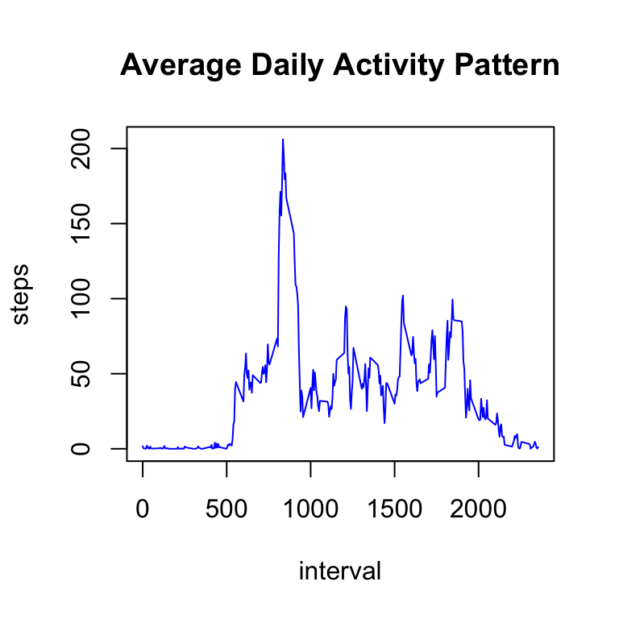

```r
with(steps_per_interval,plot(interval,steps, type = "l",
                             main = "Average Daily Activity Pattern", col = "blue"))
```

Find the 5-minute interval, on average across all the days in the dataset, that contains the maximum number of steps:

```r
print(max <- steps_per_interval$interval[which.max(steps_per_interval$steps)])
```

```
## [1] 835
```

*The 5-minute interval that contains the maximum number of steps is interval 835.*

## Imputing missing values

Calculate the total number of missing values in the dataset:

```r
print(na_table <- table(is.na(activity$steps)))
```

```
##
## FALSE  TRUE
## 15264  2304
```

```r
na_vals <- na_table[2]
```

*There are 2304 missing values in the dataset.*

Replace NA values:

*Where step values are missing, we are going to replace the NA values by the average number of steps on the given 5-minute interval. We are using this strategy because intuitively and as confirmed by the Average Daily Pattern plot, the number of step seems to vary greatly with the time of the day.*

```r
activity_clean <- activity
n <- dim(activity_clean)[1]

for (i in 1:n) {
  if (is.na((activity_clean$steps)[i])) {
    na_entry <- activity[i,]
    na_entry_interval <- na_entry[3]
    j <- match(na_entry_interval,steps_per_interval$interval)
    activity_clean$steps[i] <- steps_per_interval$steps[j]
  }
}

summary(activity_clean)
```

```
##      steps             date               interval
##  Min.   :  0.00   Min.   :2012-10-01   Min.   :   0.0
##  1st Qu.:  0.00   1st Qu.:2012-10-16   1st Qu.: 588.8
##  Median :  0.00   Median :2012-10-31   Median :1177.5
##  Mean   : 37.38   Mean   :2012-10-31   Mean   :1177.5
##  3rd Qu.: 27.00   3rd Qu.:2012-11-15   3rd Qu.:1766.2
##  Max.   :806.00   Max.   :2012-11-30   Max.   :2355.0
```

Aggregate total number of steps by day, after NA replacement:

```r
aggregated_activity_clean <- aggregate(steps~date, data = activity_clean, FUN = "sum" )
```

Create a new histogram of the total number of steps taken each day, after NA replacement:

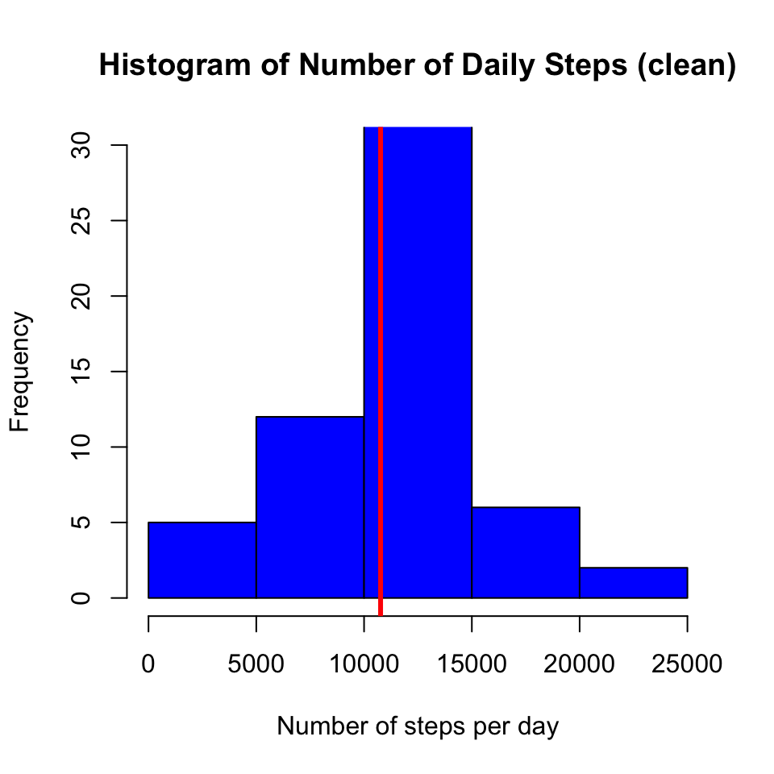

```r
hist(aggregated_activity_clean$steps, col = "blue", main = "Histogram of Number of Daily Steps (clean)", xlab = "Number of steps per day", ylim = c(0,30))
abline(v = median(aggregated_activity_clean$steps), col = "red", lwd = 3)
```

Calculate the new mean and median of the total steps taken each day, after NA replacement:

```r
print(mean <- mean(aggregated_activity_clean$steps))
```

```
## [1] 10766.19
```

```r
print(median <- median(aggregated_activity_clean$steps))
```

```
## [1] 10766.19
```

## Are there differences in activity patterns between weekdays and weekends?

Create a new variable which describe whether the day is a week-day or week-end:

```r
day_of_week <- weekdays(activity_clean$date)
activity_clean$weekday_or_weekend <- 0
n <- length(day_of_week)

for (i in 1:n) {
  if (day_of_week[i] %in% c("Saturday", "Sunday")) {
    activity_clean$weekday_or_weekend[i] <- "weekend"
  }
    else {
      activity_clean$weekday_or_weekend[i] <- "weekday"
    }
}

activity_clean$weekday_or_weekend <- as.factor(activity_clean$weekday_or_weekend)
summary(activity_clean)
```

```
##      steps             date               interval      weekday_or_weekend
##  Min.   :  0.00   Min.   :2012-10-01   Min.   :   0.0   weekday:12960
##  1st Qu.:  0.00   1st Qu.:2012-10-16   1st Qu.: 588.8   weekend: 4608
##  Median :  0.00   Median :2012-10-31   Median :1177.5
##  Mean   : 37.38   Mean   :2012-10-31   Mean   :1177.5
##  3rd Qu.: 27.00   3rd Qu.:2012-11-15   3rd Qu.:1766.2
##  Max.   :806.00   Max.   :2012-11-30   Max.   :2355.0
```

Compute average number of steps per interval, averaged across all weekday days or weekend days :

```r
activity_weekday <- subset(activity_clean, weekday_or_weekend == "weekday")
activity_weekend <- subset(activity_clean, weekday_or_weekend == "weekend")

steps_per_interval_weekday <- aggregate(steps~interval, data = activity_weekday,
                                        FUN = "mean" )
steps_per_interval_weekend <- aggregate(steps~interval, data = activity_weekend,
                                        FUN = "mean" )
```

Plot average number of steps against interval for both weekdays and weekend:

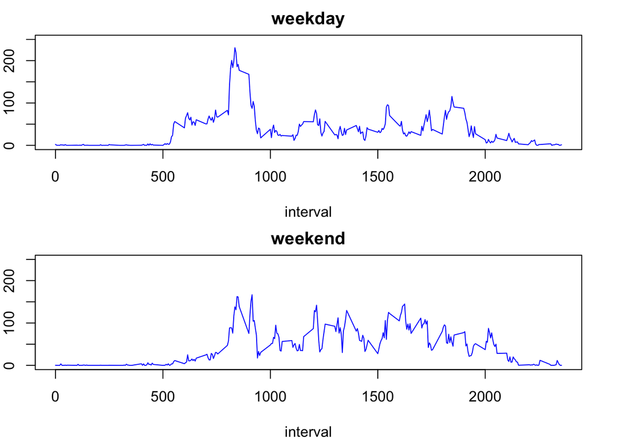

```r
par(mfrow = c(2, 1), mar = c(4,2,2,2))
with(steps_per_interval_weekday,plot(interval,steps, type = "l",
                             main = "weekday", col = "blue", ylim = c(0,250)))
with(steps_per_interval_weekend,plot(interval,steps, type = "l",
                             main = "weekend", col = "blue", ylim = c(0,250)))
```

*We can see that the pattern is quite different whether we’re on a weekday or a weekend day.*